# R Notebook

```r
if (!requireNamespace("BiocManager", quietly = TRUE))
    install.packages("BiocManager")

BiocManager::install(c("apeglm","DESeq2", "tidyverse", "ggrepel", "ggplot2", "fgsea", "pheatmap", "calibrate", "gridtext", "msigdbr", "DT"))
```

```r
library("apeglm")
library("DESeq2")
library("tidyverse")
library("ggrepel")
library("ggplot2")
```

```r
count_matrix <- read.table("/project/rivanna-training/rna-seq_21/BIOINFORMATICS-CORE-RNASEQ-WORKSHOP-OCT-NOV-2021/rnaseq_workshop_Gene_Count_Table.txt", header=TRUE, row.names=1)
metadata <- read.table("/project/rivanna-training/rna-seq_21/BIOINFORMATICS-CORE-RNASEQ-WORKSHOP-OCT-NOV-2021/metadata.txt", header = TRUE, sep = ",")
metadata
```

| Sample_Name | Sample | Group |
| --- | --- | --- |
| Naive-memory-sample-1 | NM1 | Naive |
| Naive-memory-sample-2 | NM2 | Naive |
| Naive-memory-sample-3 | NM3 | Naive |
| Naive-memory-sample-4 | NM4 | Naive |
| OMCP-memory-sample-1 | OMPC1 | OMPC |
| OMCP-memory-sample-2 | OMPC2 | OMPC |
| OMCP-memory-sample-3 | OMPC3 | OMPC |

```r
# measure the effect of treatment, controlling for sample level differences
dds <- DESeqDataSetFromMatrix(count_matrix, metadata, ~Group)
dds$Group <- relevel(dds$Group, "Naive")
idx <- rowSums( counts(dds) >= 5 ) >= 2 # atleast 2 samples (out of 7 here) have value greater than or equal to 5
dds <- dds[idx,]
dds <- DESeq(dds)
# Write out normalized counts
library(tidyverse)
dds %>% counts(normalized=TRUE) %>% write.csv("/home/pk7z/rnaseq_workshop_Gene_Count_Table-txi-normcounts.txt")
```

## Importnat information

Blind dispersion estimation The two functions, vst and rlog have an argument blind, for whether the transformation should be blind to the sample information specified by the design formula. When blind equals TRUE (the default), the functions will re-estimate the dispersions using only an intercept. This setting should be used in order to compare samples in a manner wholly unbiased by the information about experimental groups, for example to perform sample QA (quality assurance) as demonstrated below.

However, blind dispersion estimation is not the appropriate choice if one expects that many or the majority of genes (rows) will have large differences in counts which are explainable by the experimental design, and one wishes to transform the data for downstream analysis. In this case, using blind dispersion estimation will lead to large estimates of dispersion, as it attributes differences due to experimental design as unwanted noise, and will result in overly shrinking the transformed values towards each other. By setting blind to FALSE, the dispersions already estimated will be used to perform transformations, or if not present, they will be estimated using the current design formula. Note that only the fitted dispersion estimates from mean-dispersion trend line are used in the transformation (the global dependence of dispersion on mean for the entire experiment). So setting blind to FALSE is still for the most part not using the information about which samples were in which experimental group in applying the transformation.

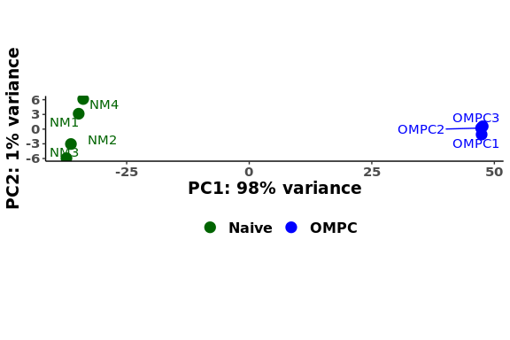

```r
##################PCA plot#################
rld = rlog(dds, blind = FALSE)
library(ggrepel)
library(ggplot2)
plotpca <- plotPCA(rld, intgroup = c("Group"), returnData = TRUE)
percentVar <- round(100 * attr(plotpca, "percentVar"))
ggplot(data = plotpca, aes(PC1, PC2, color=metadata$Group)) + geom_point(aes(colour = metadata$Group),size=4) +
  geom_text_repel(aes(PC1, PC2, label = metadata$Sample)) +   xlab(paste0("PC1: ",percentVar[1],"% variance")) +
  ylab(paste0("PC2: ",percentVar[2],"% variance")) +  coord_fixed() + scale_color_manual(values = c("darkgreen","blue","black","red","burlywood4","cadetblue","chocolate4")) + theme_bw() + theme(panel.border = element_blank(), panel.grid.major = element_blank(),
panel.grid.minor = element_blank(), axis.line = element_line(colour = "black")) + theme( axis.title.x = element_text(color="black", size=14, face="bold"), axis.title.y = element_text(color="black", size=14, face="bold")) + theme(legend.text = element_text(color = "black", size = 12, face="bold")) + theme(legend.title=element_blank()) + theme(text = element_text(size=14, face="bold")) +  theme(legend.position="bottom")
```

## Samples are clustering based on their group

```r
########################## MA plot for Group_OMPC_vs_Naive ##################################
# lfcShrink is for shrunken log2 fold changes, which remove the noise associated with log2 fold changes from low count genes
library("apeglm")
resultsNames(dds)
```

```
[1] "Intercept"           "Group_OMPC_vs_Naive"
```

```r
res <- results(dds, name="Group_OMPC_vs_Naive", tidy = TRUE)
resLFC <- lfcShrink(dds, coef="Group_OMPC_vs_Naive", type="apeglm")
```

```
using 'apeglm' for LFC shrinkage. If used in published research, please cite:
    Zhu, A., Ibrahim, J.G., Love, M.I. (2018) Heavy-tailed prior distributions for
    sequence count data: removing the noise and preserving large differences.
    Bioinformatics. https://doi.org/10.1093/bioinformatics/bty895
```

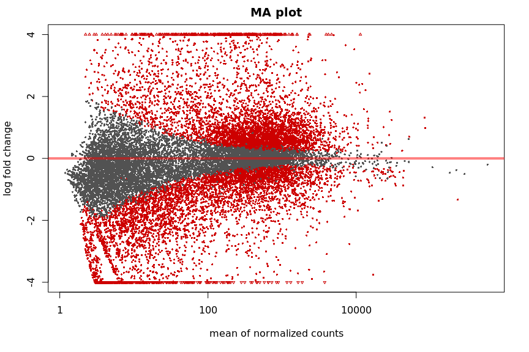

```r
plotMA(resLFC, xlab = "mean of normalized counts", alpha = 0.05, main = "MA plot", ylim=c(-4,4))
```

```r
# write files for data needed for volcano plots
write.table(res, "/home/pk7z/rnaseq_workshop_Gene_Count_Table-res.Group_OMPC_vs_Naive.txt", sep="\t") # need this for the volcano plot, edit to add
# write files for significant DEG's, FDR is 5%
res_sig <- subset(res, padj < 0.05)
write.table(res_sig, "/home/pk7z/rnaseq_workshop_Gene_Count_Table-res.Group_OMPC_vs_Naive_sig0.05.txt", sep="\t")
```

```r
BiocManager::install(c("calibrate", "gridtext"))
```

```r
################################ Volcano plot for Group_OMPC_vs_Naive #########################################
library(dplyr)
library(calibrate)
library(ggrepel)
library(gridtext)
# file was edited to have the header "GeneId"############Important##########
res <- read.table("/home/pk7z/rnaseq_workshop_Gene_Count_Table-res.Group_OMPC_vs_Naive.txt", header=TRUE)
#check for setting X limits
range(res$log2FoldChange) #-6.917511 10.919991
```

```
[1] -9.692158  9.136119
```

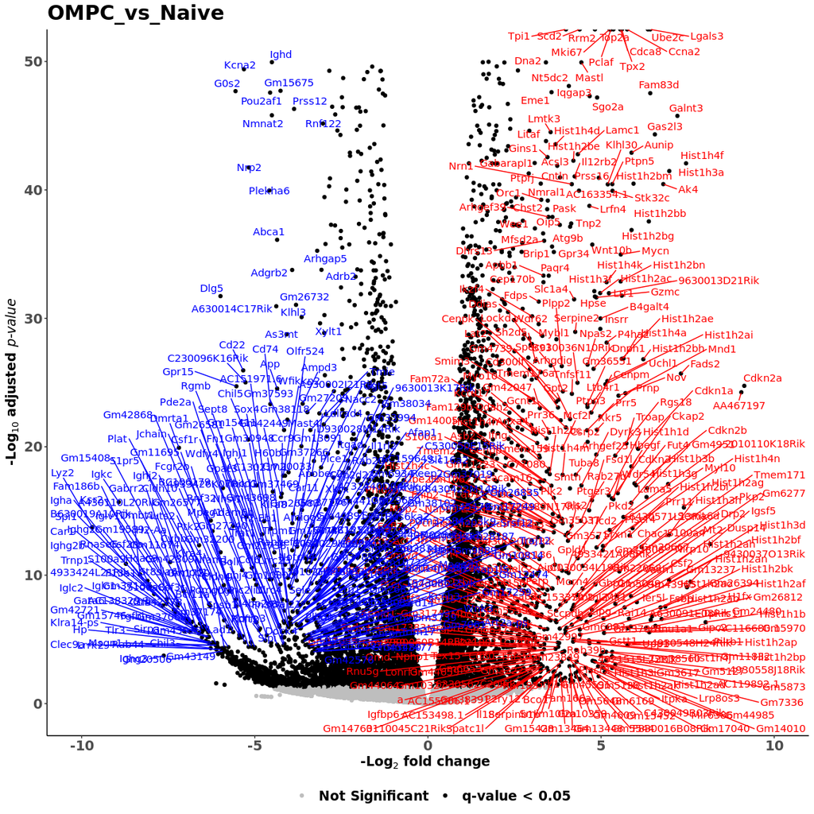

```r
results = mutate(res, sig=ifelse(res$padj<0.05, "q-value < 0.05", "Not Significant"))
#This line added later
results <- results %>% filter ((!results$sig == "NA"))
#For Y axis lab
Y_axi_lab <- expression(bold(paste("-Log"[10] , " adjusted ", italic("p-value"))))
X_axi_lab <- expression(bold(paste("-Log" [2] , " fold change ")))
#This print grey and black (start)
p = ggplot(results, aes(log2FoldChange, -log10(padj))) + ggtitle("OMPC_vs_Naive") +
  theme(plot.title = element_text(hjust = 0.5)) +
  geom_point(aes(col=sig)) +
  scale_color_manual(values=c("grey", "black")) +
 xlim(-10, +10) + ylim(0, 50)
p = p+geom_text_repel(data=filter(results, padj<0.01,log2FoldChange>=3), aes(label=row), color="Red", max.overlaps = 100)
p = p+geom_text_repel(data=filter(results, padj<0.01,log2FoldChange<=-3), aes(label=row), color="Blue", max.overlaps = 100) + theme_bw() + theme(panel.border = element_blank(), panel.grid.major = element_blank(),
panel.grid.minor = element_blank(), axis.line = element_line(colour = "black")) +  theme(legend.text = element_text(color = "black", size = 14, face="bold")) + theme(legend.title=element_blank())  + labs(y=Y_axi_lab, x=X_axi_lab) + theme(legend.position="bottom") + theme( axis.title.x = element_text(color="black", size=14, face="bold"), axis.title.y = element_text(color="black", size=14, face="bold")) + theme(text = element_text(size=18, face="bold"))
p
```

## Heatmap of top 100 genes selected based on adjusted p -value

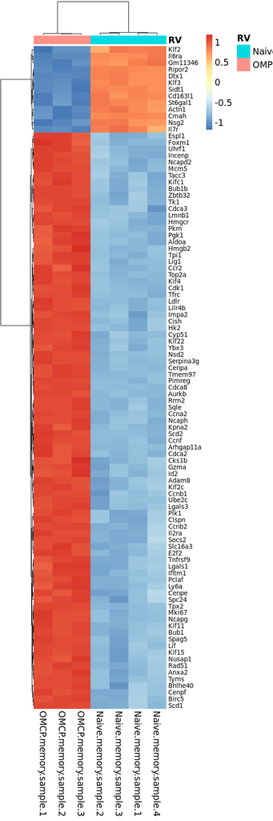

```r
library("pheatmap")
mat = assay(rld)[ head(order(res$padj),100), ] # select the top 100 genes with the lowest padj
mat = mat - rowMeans(mat) # Subtract the row means from each value
# Optional, but to make the plot nicer:
df = as.data.frame(colData(rld)[,c("Group")]) # Create a dataframe with a column of the conditions
colnames(df) = "RV" # Rename the column header
rownames(df) = colnames(mat) # add rownames
# and plot the actual heatmap
pheatmap(mat, annotation_col=df, scale = "row", fontsize_row = 10.0, fontsize = 14, cellwidth = 30)
```

```r
#install.packages("msigdbr")
library(msigdbr)
library(fgsea)
```

## Pathway Analysis (Group_OMPC_vs_Naive)

## Load the DESeq result. Here all you’ll care is the gene symbol and the test statistic. Get just those.

```r
res2 <- res %>%
  dplyr::select(row, stat) %>%
  na.omit() %>%
  distinct() %>%
  group_by(row) %>%
  summarize(stat=mean(stat))
```

## Now create named vector of test statistics.

```r
ranks <- deframe(res2)
head(ranks, 20)
```

```
0610005C13Rik 0610009B22Rik 0610009E02Rik 0610009L18Rik 0610009O20Rik 0610010F05Rik 0610010K14Rik 0610012D04Rik 0610012G03Rik 0610030E20Rik 0610037L13Rik 0610038B21Rik
   0.08546083    2.34530683    0.70780661   -5.26899998    6.75892991    8.45054335   -0.71708995   -2.03326972    4.82345040   -5.47917735   -3.05515331   -1.52965179
0610039K10Rik 0610040B10Rik 0610043K17Rik 1010001B22Rik 1110002J07Rik 1110002L01Rik 1110003F10Rik 1110004E09Rik
   0.07699417   -0.53099653   -3.30282253   -1.32460528   -1.69997295   -3.65414171    0.37549050    5.10932239
```

```r
m_df<- msigdbr(species = "Mus musculus", category = "H")
head(m_df)
```

| gs_cat | gs_subcat | gs_name | gene_symbol | entrez_gene | ensembl_gene | human_gene_symbol | human_entrez_gene | human_ensembl_gene | gs_id | gs_pmid | gs_geoid | gs_exact_source | gs_url | gs_description | taxon_id | ortholog_sources | num_ortholog_sources |
| --- | --- | --- | --- | --- | --- | --- | --- | --- | --- | --- | --- | --- | --- | --- | --- | --- | --- |
| H |  | HALLMARK_ADIPOGENESIS | Abca1 | 11303 | ENSMUSG00000015243 | ABCA1 | 19 | ENSG00000165029 | M5905 |  |  |  |  | Genes up-regulated during adipocyte differentiation (adipogenesis). | 10090 | EggNOG\|Ensembl\|HGNC\|HomoloGene\|Inparanoid\|NCBI\|OMA\|OrthoDB\|OrthoMCL\|Panther\|Treefam | 11 |
| H |  | HALLMARK_ADIPOGENESIS | Abcb8 | 74610 | ENSMUSG00000028973 | ABCB8 | 11194 | ENSG00000197150 | M5905 |  |  |  |  | Genes up-regulated during adipocyte differentiation (adipogenesis). | 10090 | EggNOG\|Ensembl\|HGNC\|HomoloGene\|Inparanoid\|NCBI\|OMA\|OrthoDB\|OrthoMCL\|Panther\|PhylomeDB\|Treefam | 12 |
| H |  | HALLMARK_ADIPOGENESIS | Acaa2 | 52538 | ENSMUSG00000036880 | ACAA2 | 10449 | ENSG00000167315 | M5905 |  |  |  |  | Genes up-regulated during adipocyte differentiation (adipogenesis). | 10090 | EggNOG\|Ensembl\|HGNC\|HomoloGene\|Inparanoid\|NCBI\|OMA\|OrthoDB\|OrthoMCL\|Panther\|Treefam | 11 |
| H |  | HALLMARK_ADIPOGENESIS | Acadl | 11363 | ENSMUSG00000026003 | ACADL | 33 | ENSG00000115361 | M5905 |  |  |  |  | Genes up-regulated during adipocyte differentiation (adipogenesis). | 10090 | EggNOG\|Ensembl\|HGNC\|HomoloGene\|Inparanoid\|NCBI\|OMA\|OrthoDB\|OrthoMCL\|Panther\|Treefam | 11 |
| H |  | HALLMARK_ADIPOGENESIS | Acadm | 11364 | ENSMUSG00000062908 | ACADM | 34 | ENSG00000117054 | M5905 |  |  |  |  | Genes up-regulated during adipocyte differentiation (adipogenesis). | 10090 | EggNOG\|Ensembl\|HGNC\|HomoloGene\|Inparanoid\|NCBI\|OMA\|OrthoDB\|OrthoMCL\|Panther\|PhylomeDB\|Treefam | 12 |
| H |  | HALLMARK_ADIPOGENESIS | Acads | 11409 | ENSMUSG00000029545 | ACADS | 35 | ENSG00000122971 | M5905 |  |  |  |  | Genes up-regulated during adipocyte differentiation (adipogenesis). | 10090 | EggNOG\|Ensembl\|HGNC\|HomoloGene\|Inparanoid\|NCBI\|OMA\|OrthoDB\|OrthoMCL\|Panther\|Treefam | 11 |

```r
fgsea_sets<- m_df %>% split(x = .$gene_symbol, f = .$gs_name)
fgsea_sets%>%
  head() %>%
  lapply(head)
```

```
$HALLMARK_ADIPOGENESIS
[1] "Abca1" "Abcb8" "Acaa2" "Acadl" "Acadm" "Acads"

$HALLMARK_ALLOGRAFT_REJECTION
[1] "Aars"   "Abce1"  "Abi1"   "Ache"   "Acvr2a" "Akt1"

$HALLMARK_ANDROGEN_RESPONSE
[1] "Abcc4"   "Abhd2"   "Acsl3"   "Actn1"   "Adamts1" "Adrm1"

$HALLMARK_ANGIOGENESIS
[1] "Apoh"   "App"    "Ccnd2"  "Col3a1" "Col5a2" "Cxcl5"

$HALLMARK_APICAL_JUNCTION
[1] "Acta1" "Actb"  "Actc1" "Actg1" "Actg2" "Actn1"

$HALLMARK_APICAL_SURFACE
[1] "Adam10"   "Adipor2"  "Afap1l2"  "Akap7"    "App"      "Atp6v0a4"
```

```r
fgseaRes<- fgseaMultilevel(fgsea_sets, stats = ranks)
```

```
There are ties in the preranked stats (0.5% of the list).
The order of those tied genes will be arbitrary, which may produce unexpected results.
```

```r
#BiocManager::install("DT")
```

```r
fgseaResTidy <- fgseaRes %>%
  as_tibble() %>%
  arrange(desc(NES))
# Show in a nice table:
fgseaResTidy %>%
  dplyr::select(-leadingEdge, -ES, -log2err) %>%
  arrange(padj) %>%
  DT::datatable()
```

|  | pathway | pval | padj | NES | size |
| --- | --- | --- | --- | --- | --- |
| 1 | HALLMARK_E2F_TARGETS | 6.17080275083273e-66 | 3.08540137541637e-64 | 3.01405752714701 | 197 |
| 2 | HALLMARK_G2M_CHECKPOINT | 5.77536036135595e-53 | 1.44384009033899e-51 | 2.89731646189412 | 192 |
| 3 | HALLMARK_MTORC1_SIGNALING | 1.47545516217666e-39 | 2.4590919369611e-38 | 2.74402543645523 | 193 |
| 4 | HALLMARK_MYC_TARGETS_V1 | 4.21679077007069e-35 | 5.27098846258837e-34 | 2.67872344287835 | 200 |
| 5 | HALLMARK_GLYCOLYSIS | 4.83254127860908e-19 | 4.83254127860908e-18 | 2.40370899090883 | 167 |
| 6 | HALLMARK_OXIDATIVE_PHOSPHORYLATION | 5.85040993013878e-16 | 4.87534160844898e-15 | 2.25005147093694 | 196 |
| 7 | HALLMARK_CHOLESTEROL_HOMEOSTASIS | 2.64652496080254e-15 | 1.89037497200181e-14 | 2.47273694335791 | 64 |
| 8 | HALLMARK_IL2_STAT5_SIGNALING | 2.52632270242883e-14 | 1.57895168901802e-13 | 2.1726045206972 | 188 |
| 9 | HALLMARK_HYPOXIA | 2.20887537665843e-13 | 1.22715298703246e-12 | 2.20480741558649 | 158 |
| 10 | HALLMARK_MITOTIC_SPINDLE | 2.57554450377169e-11 | 1.28777225188584e-10 | 2.06553610448794 | 192 |

[output cut: 40 more lines]

## Some PI like list of enriched pathway based on p-value

```r
topPathwaysUp <- fgseaRes[ES > 0][head(order(pval), n=10), pathway]
topPathwaysUp
```

```
 [1] "HALLMARK_E2F_TARGETS"               "HALLMARK_G2M_CHECKPOINT"            "HALLMARK_MTORC1_SIGNALING"          "HALLMARK_MYC_TARGETS_V1"
 [5] "HALLMARK_GLYCOLYSIS"                "HALLMARK_OXIDATIVE_PHOSPHORYLATION" "HALLMARK_CHOLESTEROL_HOMEOSTASIS"   "HALLMARK_IL2_STAT5_SIGNALING"
 [9] "HALLMARK_HYPOXIA"                   "HALLMARK_MITOTIC_SPINDLE"
```

```r
topPathwaysDown <- fgseaRes[ES < 0][head(order(pval), n=10), pathway]
topPathwaysDown
```

```
[1] "HALLMARK_KRAS_SIGNALING_UP"          "HALLMARK_WNT_BETA_CATENIN_SIGNALING" "HALLMARK_NOTCH_SIGNALING"            "HALLMARK_TGF_BETA_SIGNALING"
[5] "HALLMARK_KRAS_SIGNALING_DN"          "HALLMARK_APICAL_SURFACE"             "HALLMARK_PANCREAS_BETA_CELLS"
```

## Group_OMPC_vs_Naive

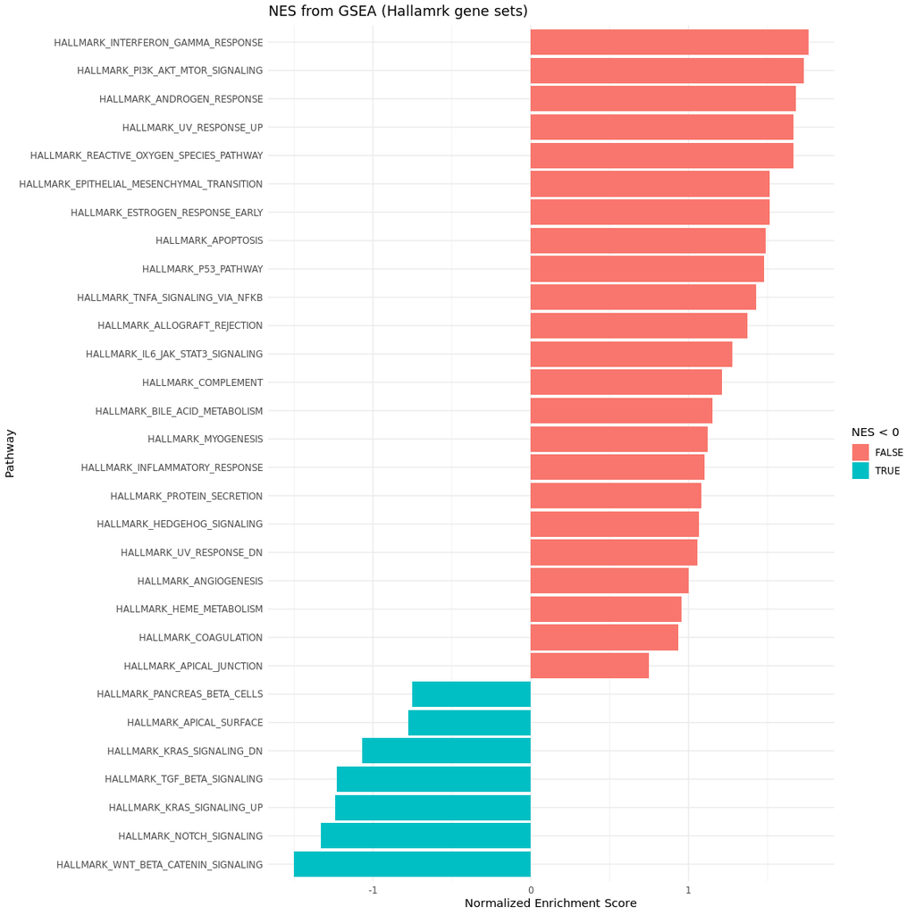

```r
ggplot(fgseaResTidy %>% arrange(NES) %>% head(n= 30), aes(reorder(pathway, NES), NES)) +
  geom_col(aes(fill=NES<0)) +
  coord_flip() +
  labs(x="Pathway", y="Normalized Enrichment Score",
       title="NES from GSEA (Hallamrk gene sets)") +
  theme_minimal()
```

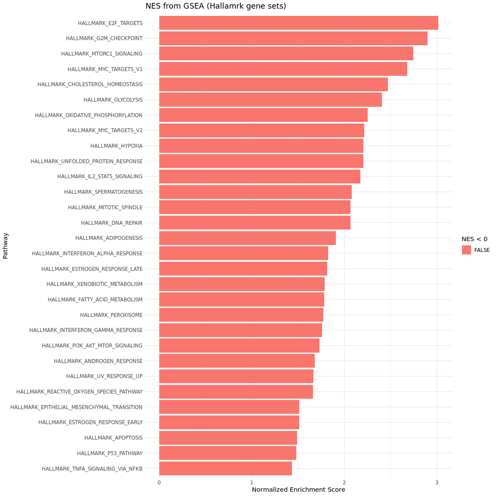

```r
ggplot(fgseaResTidy %>% arrange(padj) %>% head(n= 30), aes(reorder(pathway, NES), NES)) +
  geom_col(aes(fill=NES<0)) +
  coord_flip() +
  labs(x="Pathway", y="Normalized Enrichment Score",
       title="NES from GSEA (Hallamrk gene sets)") +
  theme_minimal()
```